# 4. Ders: Olasılık I

Çalışma soruları

← Çalışma soruları · Sunum

## Kavramları yoklama

Bir para üç kez atılıyor (T: tura, Y: yazı). $A$ olayı en az 2 tura gelmesi, $B$ olayı ilk atışın tura gelmesi olsun.

- Örneklem uzayındaki sonuç sayısı $|S|$:
- $A$ olayındaki sonuç sayısı:
- $A \cap B$ olayındaki sonuç sayısı:

Her atışın 2 sonucu var; çarpım kuralıyla $|S| = 2 \times 2 \times 2 = 8$.

$A = \{TTT,\ YTT,\ TYT,\ TTY\}$: **4** sonuç.

$A \cap B$, $A$’nın sonuçlarından $B$’yi de sağlayanlardır: $A \cap B = \{TTT,\ TYT,\ TTY\}$, yani **3** sonuç.

Olayları önce küme olarak yazmak, sonra saymak hatayı azaltır.

İki zar atılıyor; sonuçlar (birinci zar, ikinci zar) sıralı ikilileriyle yazılıyor. $A$ olayı iki zarın aynı gelmesi, $B$ olayı ikinci zarın 4’ten büyük gelmesi olsun.

- Örneklem uzayındaki sonuç sayısı $|S|$:
- $A$ olayındaki sonuç sayısı:
- $A \cap B$ olayındaki sonuç sayısı:

Her zarın 6 sonucu var; çarpım kuralıyla $|S| = 6 \times 6 = 36$ sıralı ikili.

$A = \{(1,1),\ (2,2),\ (3,3),\ (4,4),\ (5,5),\ (6,6)\}$: **6** sonuç.

$A \cap B$, $A$’nın sonuçlarından $B$’yi de sağlayanlardır: $A \cap B = \{(5,5),\ (6,6)\}$, yani **2** sonuç.

Olayları önce küme olarak yazmak, sonra saymak hatayı azaltır. (1,2) ile (2,1) farklı sonuçlardır: zarlar ayırt edilebilir.

Bir para üç kez atılıyor (T: tura, Y: yazı). $A$ olayı tam 1 tura gelmesi, $B$ olayı son atışın yazı gelmesi olsun.

- Örneklem uzayındaki sonuç sayısı $|S|$:
- $A$ olayındaki sonuç sayısı:
- $A \cap B$ olayındaki sonuç sayısı:

Her atışın 2 sonucu var; çarpım kuralıyla $|S| = 2 \times 2 \times 2 = 8$.

$A = \{YYT,\ YTY,\ TYY\}$: **3** sonuç.

$A \cap B$, $A$’nın sonuçlarından $B$’yi de sağlayanlardır: $A \cap B = \{YTY,\ TYY\}$, yani **2** sonuç.

Olayları önce küme olarak yazmak, sonra saymak hatayı azaltır.

İki zar atılıyor; sonuçlar (birinci zar, ikinci zar) sıralı ikilileriyle yazılıyor. $A$ olayı iki zarın aynı gelmesi, $B$ olayı toplamın çift olması olsun.

- Örneklem uzayındaki sonuç sayısı $|S|$:
- $A$ olayındaki sonuç sayısı:
- $A \cap B$ olayındaki sonuç sayısı:

Her zarın 6 sonucu var; çarpım kuralıyla $|S| = 6 \times 6 = 36$ sıralı ikili.

$A = \{(1,1),\ (2,2),\ (3,3),\ (4,4),\ (5,5),\ (6,6)\}$: **6** sonuç.

$A \cap B$, $A$’nın sonuçlarından $B$’yi de sağlayanlardır: $A \cap B = \{(1,1),\ (2,2),\ (3,3),\ (4,4),\ (5,5),\ (6,6)\}$, yani **6** sonuç.

Burada $A$’nın bütün sonuçları $B$’yi de sağlıyor: $A \subset B$, bu yüzden $A \cap B = A$. Olayları önce küme olarak yazmak, sonra saymak hatayı azaltır. (1,2) ile (2,1) farklı sonuçlardır: zarlar ayırt edilebilir.

İki zar atılıyor ve **toplam** gözleniyor; toplamın alabileceği değerler $\{2, 3, \ldots, 12\}$. $A$: toplamın tek olması; $B$: toplam $< 7$.

- $A \cap B$:
- $A \cup B$:
- $\bar{A}$:
- $\bar{A} \cap B$:

$A$ = {3, 5, 7, 9, 11}, $B$ = {2, 3, 4, 5, 6}.

- $A \cap B$ (ikisi birlikte): {3, 5}
- $A \cup B$ (en az biri): {2, 3, 4, 5, 6, 7, 9, 11}
- $\bar{A}$ ($A$’nın dışında kalanlar): {2, 4, 6, 8, 10, 12}
- $\bar{A} \cap B$ ($B$’de olup $A$’da olmayanlar): {2, 4, 6}

Denetim: $A \cup \bar{A}$ bütün değerleri verir ve $A \cap \bar{A} = \emptyset$.

İki zar atılıyor ve **toplam** gözleniyor; toplamın alabileceği değerler $\{2, 3, \ldots, 12\}$. $A$: toplamın 3’e tam bölünmesi; $B$: toplam $< 8$.

- $A \cap B$:
- $A \cup B$:
- $\bar{A}$:
- $\bar{A} \cap B$:

$A$ = {3, 6, 9, 12}, $B$ = {2, 3, 4, 5, 6, 7}.

- $A \cap B$ (ikisi birlikte): {3, 6}
- $A \cup B$ (en az biri): {2, 3, 4, 5, 6, 7, 9, 12}
- $\bar{A}$ ($A$’nın dışında kalanlar): {2, 4, 5, 7, 8, 10, 11}
- $\bar{A} \cap B$ ($B$’de olup $A$’da olmayanlar): {2, 4, 5, 7}

Denetim: $A \cup \bar{A}$ bütün değerleri verir ve $A \cap \bar{A} = \emptyset$.

İki zar atılıyor ve **toplam** gözleniyor; toplamın alabileceği değerler $\{2, 3, \ldots, 12\}$. $A$: toplamın çift olması; $B$: toplam $> 6$.

- $A \cap B$:
- $A \cup B$:
- $\bar{A}$:
- $\bar{A} \cap B$:

$A$ = {2, 4, 6, 8, 10, 12}, $B$ = {7, 8, 9, 10, 11, 12}.

- $A \cap B$ (ikisi birlikte): {8, 10, 12}
- $A \cup B$ (en az biri): {2, 4, 6, 7, 8, 9, 10, 11, 12}
- $\bar{A}$ ($A$’nın dışında kalanlar): {3, 5, 7, 9, 11}
- $\bar{A} \cap B$ ($B$’de olup $A$’da olmayanlar): {7, 9, 11}

Denetim: $A \cup \bar{A}$ bütün değerleri verir ve $A \cap \bar{A} = \emptyset$.

İki zar atılıyor ve **toplam** gözleniyor; toplamın alabileceği değerler $\{2, 3, \ldots, 12\}$. $A$: toplamın çift olması; $B$: toplam $< 7$.

- $A \cap B$:
- $A \cup B$:
- $\bar{A}$:
- $\bar{A} \cap B$:

$A$ = {2, 4, 6, 8, 10, 12}, $B$ = {2, 3, 4, 5, 6}.

- $A \cap B$ (ikisi birlikte): {2, 4, 6}
- $A \cup B$ (en az biri): {2, 3, 4, 5, 6, 8, 10, 12}
- $\bar{A}$ ($A$’nın dışında kalanlar): {3, 5, 7, 9, 11}
- $\bar{A} \cap B$ ($B$’de olup $A$’da olmayanlar): {3, 5}

Denetim: $A \cup \bar{A}$ bütün değerleri verir ve $A \cap \bar{A} = \emptyset$.

Bir öğrenci bir dersi alıyor. $A$: dersten geçmesi, $B$: dersten kalması.

- $A$ ile $B$ ayrık (karşılıklı bağdaşmaz) mı?
- $A$ ile $B$ bütünü kapsayıcı mı?

Ayrık: **evet**. Bütünü kapsayıcı: **evet**. Bir öğrenci hem geçip hem kalamaz ve ikisinden biri mutlaka olur.

- **Ayrık:** ortak sonucu yok, kesişimleri boş küme: $A \cap B = \emptyset$. İkisi aynı anda gerçekleşemez.
- **Bütünü kapsayıcı:** birleşimleri örneklem uzayının tamamı: $A \cup B = S$. İkisinden en az biri mutlaka gerçekleşir.

Bunlar birbirinden ayrı iki özelliktir: dört birleşimin dördü de mümkündür. İkisi birlikte sağlanıyorsa olaylar örneklem uzayını parçalara ayırır; iki olay için bu $B = \bar{A}$ demektir.

Bir zar atılıyor. $A = \{1, 3, 5\}$, $B = \{2, 4, 6\}$.

- $A$ ile $B$ ayrık (karşılıklı bağdaşmaz) mı?
- $A$ ile $B$ bütünü kapsayıcı mı?

Ayrık: **evet**. Bütünü kapsayıcı: **evet**. Ortak sonuç yok ve birleşimleri bütün örneklem uzayı.

- **Ayrık:** ortak sonucu yok, kesişimleri boş küme: $A \cap B = \emptyset$. İkisi aynı anda gerçekleşemez.
- **Bütünü kapsayıcı:** birleşimleri örneklem uzayının tamamı: $A \cup B = S$. İkisinden en az biri mutlaka gerçekleşir.

Bunlar birbirinden ayrı iki özelliktir: dört birleşimin dördü de mümkündür. İkisi birlikte sağlanıyorsa olaylar örneklem uzayını parçalara ayırır; iki olay için bu $B = \bar{A}$ demektir.

İki zar atılıyor. $A$: toplamın 7 olması, $B$: iki zarın aynı gelmesi.

- $A$ ile $B$ ayrık (karşılıklı bağdaşmaz) mı?
- $A$ ile $B$ bütünü kapsayıcı mı?

Ayrık: **evet**. Bütünü kapsayıcı: **hayır**. Aynı iki sayının toplamı çifttir, 7 olamaz; ama örneğin (1, 2) hiçbirinde değil.

- **Ayrık:** ortak sonucu yok, kesişimleri boş küme: $A \cap B = \emptyset$. İkisi aynı anda gerçekleşemez.
- **Bütünü kapsayıcı:** birleşimleri örneklem uzayının tamamı: $A \cup B = S$. İkisinden en az biri mutlaka gerçekleşir.

Bunlar birbirinden ayrı iki özelliktir: dört birleşimin dördü de mümkündür. İkisi birlikte sağlanıyorsa olaylar örneklem uzayını parçalara ayırır; iki olay için bu $B = \bar{A}$ demektir.

İki zar atılıyor. $A$: toplamın 7 olması, $B$: iki zarın aynı gelmesi.

- $A$ ile $B$ ayrık (karşılıklı bağdaşmaz) mı?
- $A$ ile $B$ bütünü kapsayıcı mı?

Ayrık: **evet**. Bütünü kapsayıcı: **hayır**. Aynı iki sayının toplamı çifttir, 7 olamaz; ama örneğin (1, 2) hiçbirinde değil.

- **Ayrık:** ortak sonucu yok, kesişimleri boş küme: $A \cap B = \emptyset$. İkisi aynı anda gerçekleşemez.
- **Bütünü kapsayıcı:** birleşimleri örneklem uzayının tamamı: $A \cup B = S$. İkisinden en az biri mutlaka gerçekleşir.

Bunlar birbirinden ayrı iki özelliktir: dört birleşimin dördü de mümkündür. İkisi birlikte sağlanıyorsa olaylar örneklem uzayını parçalara ayırır; iki olay için bu $B = \bar{A}$ demektir.

Bir zar atılıyor. $A = \{2, 4, 6\}$, $B = \{4, 5, 6\}$.

- $A$ ile $B$ ayrık (karşılıklı bağdaşmaz) mı?
- $A$ ile $B$ bütünü kapsayıcı mı?

Ayrık: **hayır**. Bütünü kapsayıcı: **hayır**. 4 ve 6 ikisinde de var; 1 ve 3 hiçbirinde yok.

- **Ayrık:** ortak sonucu yok, kesişimleri boş küme: $A \cap B = \emptyset$. İkisi aynı anda gerçekleşemez.
- **Bütünü kapsayıcı:** birleşimleri örneklem uzayının tamamı: $A \cup B = S$. İkisinden en az biri mutlaka gerçekleşir.

Bunlar birbirinden ayrı iki özelliktir: dört birleşimin dördü de mümkündür. İkisi birlikte sağlanıyorsa olaylar örneklem uzayını parçalara ayırır; iki olay için bu $B = \bar{A}$ demektir.

Bir zar atılıyor. $A = \{1, 2\}$, $B = \{5, 6\}$.

- $A$ ile $B$ ayrık (karşılıklı bağdaşmaz) mı?
- $A$ ile $B$ bütünü kapsayıcı mı?

Ayrık: **evet**. Bütünü kapsayıcı: **hayır**. Ortak sonuç yok ama 3 ve 4 hiçbirinde değil.

- **Ayrık:** ortak sonucu yok, kesişimleri boş küme: $A \cap B = \emptyset$. İkisi aynı anda gerçekleşemez.
- **Bütünü kapsayıcı:** birleşimleri örneklem uzayının tamamı: $A \cup B = S$. İkisinden en az biri mutlaka gerçekleşir.

Bunlar birbirinden ayrı iki özelliktir: dört birleşimin dördü de mümkündür. İkisi birlikte sağlanıyorsa olaylar örneklem uzayını parçalara ayırır; iki olay için bu $B = \bar{A}$ demektir.

Bir zar atılıyor. $A = \{2, 4, 6\}$, $B = \{4, 5, 6\}$.

- $A$ ile $B$ ayrık (karşılıklı bağdaşmaz) mı?
- $A$ ile $B$ bütünü kapsayıcı mı?

Ayrık: **hayır**. Bütünü kapsayıcı: **hayır**. 4 ve 6 ikisinde de var; 1 ve 3 hiçbirinde yok.

- **Ayrık:** ortak sonucu yok, kesişimleri boş küme: $A \cap B = \emptyset$. İkisi aynı anda gerçekleşemez.
- **Bütünü kapsayıcı:** birleşimleri örneklem uzayının tamamı: $A \cup B = S$. İkisinden en az biri mutlaka gerçekleşir.

Bunlar birbirinden ayrı iki özelliktir: dört birleşimin dördü de mümkündür. İkisi birlikte sağlanıyorsa olaylar örneklem uzayını parçalara ayırır; iki olay için bu $B = \bar{A}$ demektir.

Rassal seçilen bir öğrencinin yaşı. $A$: 20’den büyük, $B$: 25’ten küçük.

- $A$ ile $B$ ayrık (karşılıklı bağdaşmaz) mı?
- $A$ ile $B$ bütünü kapsayıcı mı?

Ayrık: **hayır**. Bütünü kapsayıcı: **evet**. Her yaş iki olaydan en az birine giriyor; 21-24 yaşındakiler ikisine birden.

- **Ayrık:** ortak sonucu yok, kesişimleri boş küme: $A \cap B = \emptyset$. İkisi aynı anda gerçekleşemez.
- **Bütünü kapsayıcı:** birleşimleri örneklem uzayının tamamı: $A \cup B = S$. İkisinden en az biri mutlaka gerçekleşir.

Bunlar birbirinden ayrı iki özelliktir: dört birleşimin dördü de mümkündür. İkisi birlikte sağlanıyorsa olaylar örneklem uzayını parçalara ayırır; iki olay için bu $B = \bar{A}$ demektir.

> Bir ekonomist, gelecek yıl merkez bankasının faizi indirme olasılığını 0.7 olarak tahmin ediyor.

Bu olasılık hangi yaklaşımla belirlenmiştir?

Klasik yaklaşımGöreli sıklık yaklaşımıÖznel yaklaşım

**Öznel yaklaşım.** Olasılık, bir kişinin mevcut bilgi ve değerlendirmesine dayanan **inanç derecesini** gösteriyor. Başka biri, elindeki bilgi farklı olduğu için aynı olaya farklı bir olasılık verebilir. (Öznel olasılık yalnızca tekrarlanamayan olaylara özgü değildir; tekrarlanan olaylara da atanabilir.)

Üç yaklaşım da aynı matematiksel kurallara uyar: olasılık 0 ile 1 arasındadır, örneklem uzayının olasılığı 1’dir, ayrık olayların olasılıkları toplanır.

> Bir girişimci, yeni kurduğu şirketin beş yıl içinde halka açılma olasılığını 0.1 olarak değerlendiriyor.

Bu olasılık hangi yaklaşımla belirlenmiştir?

Klasik yaklaşımGöreli sıklık yaklaşımıÖznel yaklaşım

**Öznel yaklaşım.** Olasılık, bir kişinin mevcut bilgi ve değerlendirmesine dayanan **inanç derecesini** gösteriyor. Başka biri, elindeki bilgi farklı olduğu için aynı olaya farklı bir olasılık verebilir. (Öznel olasılık yalnızca tekrarlanamayan olaylara özgü değildir; tekrarlanan olaylara da atanabilir.)

Üç yaklaşım da aynı matematiksel kurallara uyar: olasılık 0 ile 1 arasındadır, örneklem uzayının olasılığı 1’dir, ayrık olayların olasılıkları toplanır.

> Bir sigorta şirketi, son on yılın kayıtlarına dayanarak 25 yaşındaki bir sürücünün bir yıl içinde kaza yapma olasılığını 0.08 olarak belirliyor.

Bu olasılık hangi yaklaşımla belirlenmiştir?

Klasik yaklaşımGöreli sıklık yaklaşımıÖznel yaklaşım

**Göreli sıklık yaklaşımı.** Olasılık, aynı koşullarda çok kez tekrarlanmış bir sürecin **geçmiş verisindeki oranla** belirleniyor.

Üç yaklaşım da aynı matematiksel kurallara uyar: olasılık 0 ile 1 arasındadır, örneklem uzayının olasılığı 1’dir, ayrık olayların olasılıkları toplanır.

> Bir havayolu, geçmiş uçuş kayıtlarına göre bir seferin 15 dakikadan fazla gecikme olasılığını 0.22 olarak raporluyor.

Bu olasılık hangi yaklaşımla belirlenmiştir?

Klasik yaklaşımGöreli sıklık yaklaşımıÖznel yaklaşım

**Göreli sıklık yaklaşımı.** Olasılık, aynı koşullarda çok kez tekrarlanmış bir sürecin **geçmiş verisindeki oranla** belirleniyor.

Üç yaklaşım da aynı matematiksel kurallara uyar: olasılık 0 ile 1 arasındadır, örneklem uzayının olasılığı 1’dir, ayrık olayların olasılıkları toplanır.

> 52 kartlık bir desteden çekilen kartın kupa olma olasılığı 13/52 = 0.25’tir.

Bu olasılık hangi yaklaşımla belirlenmiştir?

Klasik yaklaşımGöreli sıklık yaklaşımıÖznel yaklaşım

**Klasik yaklaşım.** Temel sonuçlar **eşit olasılıklı** kabul ediliyor ve olasılık saymayla bulunuyor: $\mathbb{P}(A) = N_A / N$.

Üç yaklaşım da aynı matematiksel kurallara uyar: olasılık 0 ile 1 arasındadır, örneklem uzayının olasılığı 1’dir, ayrık olayların olasılıkları toplanır.

> 52 kartlık bir desteden çekilen kartın kupa olma olasılığı 13/52 = 0.25’tir.

Bu olasılık hangi yaklaşımla belirlenmiştir?

Klasik yaklaşımGöreli sıklık yaklaşımıÖznel yaklaşım

**Klasik yaklaşım.** Temel sonuçlar **eşit olasılıklı** kabul ediliyor ve olasılık saymayla bulunuyor: $\mathbb{P}(A) = N_A / N$.

Üç yaklaşım da aynı matematiksel kurallara uyar: olasılık 0 ile 1 arasındadır, örneklem uzayının olasılığı 1’dir, ayrık olayların olasılıkları toplanır.

> Bir çekilişte 400 bilet satılmış; tek bilet alan birinin kazanma olasılığı 1/400 olarak hesaplanıyor.

Bu olasılık hangi yaklaşımla belirlenmiştir?

Klasik yaklaşımGöreli sıklık yaklaşımıÖznel yaklaşım

**Klasik yaklaşım.** Temel sonuçlar **eşit olasılıklı** kabul ediliyor ve olasılık saymayla bulunuyor: $\mathbb{P}(A) = N_A / N$.

Üç yaklaşım da aynı matematiksel kurallara uyar: olasılık 0 ile 1 arasındadır, örneklem uzayının olasılığı 1’dir, ayrık olayların olasılıkları toplanır.

> Bir ekonomist, gelecek yıl merkez bankasının faizi indirme olasılığını 0.7 olarak tahmin ediyor.

Bu olasılık hangi yaklaşımla belirlenmiştir?

Klasik yaklaşımGöreli sıklık yaklaşımıÖznel yaklaşım

**Öznel yaklaşım.** Olasılık, bir kişinin mevcut bilgi ve değerlendirmesine dayanan **inanç derecesini** gösteriyor. Başka biri, elindeki bilgi farklı olduğu için aynı olaya farklı bir olasılık verebilir. (Öznel olasılık yalnızca tekrarlanamayan olaylara özgü değildir; tekrarlanan olaylara da atanabilir.)

Üç yaklaşım da aynı matematiksel kurallara uyar: olasılık 0 ile 1 arasındadır, örneklem uzayının olasılığı 1’dir, ayrık olayların olasılıkları toplanır.

## Uygulama ve yorum

### Olasılık kuralları

İki hilesiz zar atılıyor. Olasılıkları dört ondalıkla veriniz.

- $\mathbb{P}(\text{toplam} = 6)$:
- $\mathbb{P}(\text{toplam en fazla } 5)$:
- $\mathbb{P}(\text{toplam } 12 \text{ ya da } 7)$:

36 sıralı ikili eşit olasılıklıdır; klasik yaklaşımla $\mathbb{P}(A) = N_A / 36$. Her toplamı veren ikili sayısı:

| Toplam | 2 | 3 | 4 | 5 | 6 | 7 | 8 | 9 | 10 | 11 | 12 |
| --- | --- | --- | --- | --- | --- | --- | --- | --- | --- | --- | --- |
| İkili sayısı | 1 | 2 | 3 | 4 | 5 | 6 | 5 | 4 | 3 | 2 | 1 |

- Toplam 6: (5,1), (4,2), (3,3), (2,4), (1,5), yani $5/36 = 0.1389$
- Toplam en fazla 5: $10/36 = 0.2778$
- Toplam 12 ile toplam 7 **ayrık** olaylardır; olasılıklar toplanır: $(1 + 6)/36 = 7/36 = 0.1944$

İki hilesiz zar atılıyor. Olasılıkları dört ondalıkla veriniz.

- $\mathbb{P}(\text{toplam} = 10)$:
- $\mathbb{P}(\text{toplam en fazla } 4)$:
- $\mathbb{P}(\text{toplam } 12 \text{ ya da } 7)$:

36 sıralı ikili eşit olasılıklıdır; klasik yaklaşımla $\mathbb{P}(A) = N_A / 36$. Her toplamı veren ikili sayısı:

| Toplam | 2 | 3 | 4 | 5 | 6 | 7 | 8 | 9 | 10 | 11 | 12 |
| --- | --- | --- | --- | --- | --- | --- | --- | --- | --- | --- | --- |
| İkili sayısı | 1 | 2 | 3 | 4 | 5 | 6 | 5 | 4 | 3 | 2 | 1 |

- Toplam 10: (6,4), (5,5), (4,6), yani $3/36 = 0.0833$
- Toplam en fazla 4: $6/36 = 0.1667$
- Toplam 12 ile toplam 7 **ayrık** olaylardır; olasılıklar toplanır: $(1 + 6)/36 = 7/36 = 0.1944$

İki hilesiz zar atılıyor. Olasılıkları dört ondalıkla veriniz.

- $\mathbb{P}(\text{toplam} = 9)$:
- $\mathbb{P}(\text{toplam en az } 9)$:
- $\mathbb{P}(\text{toplam } 11 \text{ ya da } 7)$:

36 sıralı ikili eşit olasılıklıdır; klasik yaklaşımla $\mathbb{P}(A) = N_A / 36$. Her toplamı veren ikili sayısı:

| Toplam | 2 | 3 | 4 | 5 | 6 | 7 | 8 | 9 | 10 | 11 | 12 |
| --- | --- | --- | --- | --- | --- | --- | --- | --- | --- | --- | --- |
| İkili sayısı | 1 | 2 | 3 | 4 | 5 | 6 | 5 | 4 | 3 | 2 | 1 |

- Toplam 9: (6,3), (5,4), (4,5), (3,6), yani $4/36 = 0.1111$
- Toplam en az 9: $10/36 = 0.2778$
- Toplam 11 ile toplam 7 **ayrık** olaylardır; olasılıklar toplanır: $(2 + 6)/36 = 8/36 = 0.2222$

İki hilesiz zar atılıyor. Olasılıkları dört ondalıkla veriniz.

- $\mathbb{P}(\text{toplam} = 6)$:
- $\mathbb{P}(\text{toplam en az } 8)$:
- $\mathbb{P}(\text{toplam } 11 \text{ ya da } 7)$:

36 sıralı ikili eşit olasılıklıdır; klasik yaklaşımla $\mathbb{P}(A) = N_A / 36$. Her toplamı veren ikili sayısı:

| Toplam | 2 | 3 | 4 | 5 | 6 | 7 | 8 | 9 | 10 | 11 | 12 |
| --- | --- | --- | --- | --- | --- | --- | --- | --- | --- | --- | --- |
| İkili sayısı | 1 | 2 | 3 | 4 | 5 | 6 | 5 | 4 | 3 | 2 | 1 |

- Toplam 6: (5,1), (4,2), (3,3), (2,4), (1,5), yani $5/36 = 0.1389$
- Toplam en az 8: $15/36 = 0.4167$
- Toplam 11 ile toplam 7 **ayrık** olaylardır; olasılıklar toplanır: $(2 + 6)/36 = 8/36 = 0.2222$

Bir çağrı merkezine bir saatte gelen şikâyet sayısı için olanaklı sonuçlar ve olasılıkları:

| Şikâyet sayısı | 0 | 1 | 2 | 3 | 4 | 5 |
| --- | --- | --- | --- | --- | --- | --- |
| Olasılık | 0.16 | 0.05 | 0.50 | 0.19 | 0.03 | 0.07 |

$A$: 1 taneden fazla şikâyet; $B$: çift sayıda şikâyet (0, 2 ya da 4).

- $\mathbb{P}(A)$:
- $\mathbb{P}(B)$:
- $\mathbb{P}(A \cap B)$:
- $\mathbb{P}(A \cup B)$:

Temel sonuçlar (0, 1, …, 5 şikâyet) ayrıktır; bir olayın olasılığı, içerdiği sonuçların olasılıklarının toplamıdır.

- $A = \{2, 3, 4, 5\}$: $\mathbb{P}(A) = 0.50 + 0.19 + 0.03 + 0.07 = 0.79$
- $B = \{0, 2, 4\}$: $\mathbb{P}(B) = 0.16 + 0.50 + 0.03 = 0.69$
- $A \cap B = \{2, 4\}$: $\mathbb{P}(A \cap B) = 0.50 + 0.03 = 0.53$
- Toplama kuralı: $\mathbb{P}(A \cup B) = 0.79 + 0.69 - 0.53 = 0.95$

Denetim: birleşimin dışında kalan sonuçlar $\{1\}$, olasılıkları toplamı 0.05. Tümleyenden $\mathbb{P}(A \cup B) = 1 - 0.05 = 0.95$. Kesişimi çıkarmayı unutmak, $A \cap B$’deki sonuçları iki kez saymak demektir.

Bir çağrı merkezine bir saatte gelen şikâyet sayısı için olanaklı sonuçlar ve olasılıkları:

| Şikâyet sayısı | 0 | 1 | 2 | 3 | 4 | 5 |
| --- | --- | --- | --- | --- | --- | --- |
| Olasılık | 0.22 | 0.28 | 0.17 | 0.20 | 0.07 | 0.06 |

$A$: 1 taneden fazla şikâyet; $B$: çift sayıda şikâyet (0, 2 ya da 4).

- $\mathbb{P}(A)$:
- $\mathbb{P}(B)$:
- $\mathbb{P}(A \cap B)$:
- $\mathbb{P}(A \cup B)$:

Temel sonuçlar (0, 1, …, 5 şikâyet) ayrıktır; bir olayın olasılığı, içerdiği sonuçların olasılıklarının toplamıdır.

- $A = \{2, 3, 4, 5\}$: $\mathbb{P}(A) = 0.17 + 0.20 + 0.07 + 0.06 = 0.50$
- $B = \{0, 2, 4\}$: $\mathbb{P}(B) = 0.22 + 0.17 + 0.07 = 0.46$
- $A \cap B = \{2, 4\}$: $\mathbb{P}(A \cap B) = 0.17 + 0.07 = 0.24$
- Toplama kuralı: $\mathbb{P}(A \cup B) = 0.50 + 0.46 - 0.24 = 0.72$

Denetim: birleşimin dışında kalan sonuçlar $\{1\}$, olasılıkları toplamı 0.28. Tümleyenden $\mathbb{P}(A \cup B) = 1 - 0.28 = 0.72$. Kesişimi çıkarmayı unutmak, $A \cap B$’deki sonuçları iki kez saymak demektir.

Bir mobilya fabrikasında yeni üretilen bir masanın yüzeyindeki kusur sayısı için olanaklı sonuçlar ve olasılıkları:

| Kusur sayısı | 0 | 1 | 2 | 3 | 4 | 5 |
| --- | --- | --- | --- | --- | --- | --- |
| Olasılık | 0.47 | 0.26 | 0.08 | 0.04 | 0.07 | 0.08 |

$A$: 1 taneden fazla kusur; $B$: çift sayıda kusur (0, 2 ya da 4).

- $\mathbb{P}(A)$:
- $\mathbb{P}(B)$:
- $\mathbb{P}(A \cap B)$:
- $\mathbb{P}(A \cup B)$:

Temel sonuçlar (0, 1, …, 5 kusur) ayrıktır; bir olayın olasılığı, içerdiği sonuçların olasılıklarının toplamıdır.

- $A = \{2, 3, 4, 5\}$: $\mathbb{P}(A) = 0.08 + 0.04 + 0.07 + 0.08 = 0.27$
- $B = \{0, 2, 4\}$: $\mathbb{P}(B) = 0.47 + 0.08 + 0.07 = 0.62$
- $A \cap B = \{2, 4\}$: $\mathbb{P}(A \cap B) = 0.08 + 0.07 = 0.15$
- Toplama kuralı: $\mathbb{P}(A \cup B) = 0.27 + 0.62 - 0.15 = 0.74$

Denetim: birleşimin dışında kalan sonuçlar $\{1\}$, olasılıkları toplamı 0.26. Tümleyenden $\mathbb{P}(A \cup B) = 1 - 0.26 = 0.74$. Kesişimi çıkarmayı unutmak, $A \cap B$’deki sonuçları iki kez saymak demektir.

Rassal seçilen bir hanedeki otomobil sayısı için olanaklı sonuçlar ve olasılıkları:

| Otomobil sayısı | 0 | 1 | 2 | 3 | 4 | 5 |
| --- | --- | --- | --- | --- | --- | --- |
| Olasılık | 0.13 | 0.30 | 0.16 | 0.11 | 0.12 | 0.18 |

$A$: 3 taneden fazla otomobil; $B$: en fazla 4 otomobil.

- $\mathbb{P}(A)$:
- $\mathbb{P}(B)$:
- $\mathbb{P}(A \cap B)$:
- $\mathbb{P}(A \cup B)$:

Temel sonuçlar (0, 1, …, 5 otomobil) ayrıktır; bir olayın olasılığı, içerdiği sonuçların olasılıklarının toplamıdır.

- $A = \{4, 5\}$: $\mathbb{P}(A) = 0.12 + 0.18 = 0.30$
- $B = \{0, 1, 2, 3, 4\}$: $\mathbb{P}(B) = 0.13 + 0.30 + 0.16 + 0.11 + 0.12 = 0.82$
- $A \cap B = \{4\}$: $\mathbb{P}(A \cap B) = 0.12 = 0.12$
- Toplama kuralı: $\mathbb{P}(A \cup B) = 0.30 + 0.82 - 0.12 = 1.00$

$A \cup B$ bütün sonuçları kapsıyor: $A$ ile $B$ bütünü kapsayıcı, bu yüzden $\mathbb{P}(A \cup B) = 1$. Kesişimi çıkarmayı unutmak, $A \cap B$’deki sonuçları iki kez saymak demektir.

Bir öğrencinin istatistik dersinden geçme olasılığı 0.60, mikroiktisat dersinden geçme olasılığı 0.65, ikisinden birden geçme olasılığı 0.30. Rassal seçilen biri için (üç ondalık):

- istatistik ya da mikroiktisat (en az biri):
- ikisinden **yalnızca biri**:
- hiçbiri:

$A$: istatistik, $B$: mikroiktisat. $\mathbb{P}(A) = 0.600$, $\mathbb{P}(B) = 0.650$, $\mathbb{P}(A \cap B) = 0.300$.

**En az biri (toplama kuralı):**
$$\mathbb{P}(A \cup B) = \mathbb{P}(A) + \mathbb{P}(B) - \mathbb{P}(A \cap B) = 0.600 + 0.650 - 0.300 = 0.950$$
Kesişim iki kez sayıldığı için bir kez çıkarılır.

**Yalnızca biri:** birleşimden kesişimi çıkarın: $0.950 - 0.300 = 0.650$ (ya da yalnız $A$: $0.300$, yalnız $B$: $0.350$).

**Hiçbiri:** tümleyen kuralı: $1 - 0.950 = 0.050$

Venn şemasında dört bölge vardır: yalnız $A$, $A \cap B$, yalnız $B$ ve ikisinin dışı; dördünün toplamı 1 olmalıdır.

Bir öğrencinin istatistik dersinden geçme olasılığı 0.65, mikroiktisat dersinden geçme olasılığı 0.70, ikisinden birden geçme olasılığı 0.45. Rassal seçilen biri için (üç ondalık):

- istatistik ya da mikroiktisat (en az biri):
- ikisinden **yalnızca biri**:
- hiçbiri:

$A$: istatistik, $B$: mikroiktisat. $\mathbb{P}(A) = 0.650$, $\mathbb{P}(B) = 0.700$, $\mathbb{P}(A \cap B) = 0.450$.

**En az biri (toplama kuralı):**
$$\mathbb{P}(A \cup B) = \mathbb{P}(A) + \mathbb{P}(B) - \mathbb{P}(A \cap B) = 0.650 + 0.700 - 0.450 = 0.900$$
Kesişim iki kez sayıldığı için bir kez çıkarılır.

**Yalnızca biri:** birleşimden kesişimi çıkarın: $0.900 - 0.450 = 0.450$ (ya da yalnız $A$: $0.200$, yalnız $B$: $0.250$).

**Hiçbiri:** tümleyen kuralı: $1 - 0.900 = 0.100$

Venn şemasında dört bölge vardır: yalnız $A$, $A \cap B$, yalnız $B$ ve ikisinin dışı; dördünün toplamı 1 olmalıdır.

100 çalışanı olan bir şirkette 57 çalışan İngilizce, 20 çalışan Almanca biliyor; 7 çalışan iki dili de biliyor. Rassal seçilen biri için (üç ondalık):

- İngilizce ya da Almanca (en az biri):
- ikisinden **yalnızca biri**:
- hiçbiri:

$A$: İngilizce, $B$: Almanca. $\mathbb{P}(A) = 0.570$, $\mathbb{P}(B) = 0.200$, $\mathbb{P}(A \cap B) = 0.070$.

**En az biri (toplama kuralı):**
$$\mathbb{P}(A \cup B) = \mathbb{P}(A) + \mathbb{P}(B) - \mathbb{P}(A \cap B) = 0.570 + 0.200 - 0.070 = 0.700$$
Kesişim iki kez sayıldığı için bir kez çıkarılır.

**Yalnızca biri:** birleşimden kesişimi çıkarın: $0.700 - 0.070 = 0.630$ (ya da yalnız $A$: $0.500$, yalnız $B$: $0.130$).

**Hiçbiri:** tümleyen kuralı: $1 - 0.700 = 0.300$

Venn şemasında dört bölge vardır: yalnız $A$, $A \cap B$, yalnız $B$ ve ikisinin dışı; dördünün toplamı 1 olmalıdır.

40 öğrencisi olan bir bölümde 11 öğrenci Ekonometri, 18 öğrenci Makine Öğrenmesi dersine kayıtlıdır; 6 öğrenci iki derse de kayıtlıdır. Rassal seçilen biri için (üç ondalık):

- Ekonometri ya da Makine Öğrenmesi (en az biri):
- ikisinden **yalnızca biri**:
- hiçbiri:

$A$: Ekonometri, $B$: Makine Öğrenmesi. $\mathbb{P}(A) = 0.275$, $\mathbb{P}(B) = 0.450$, $\mathbb{P}(A \cap B) = 0.150$.

**En az biri (toplama kuralı):**
$$\mathbb{P}(A \cup B) = \mathbb{P}(A) + \mathbb{P}(B) - \mathbb{P}(A \cap B) = 0.275 + 0.450 - 0.150 = 0.575$$
Kesişim iki kez sayıldığı için bir kez çıkarılır.

**Yalnızca biri:** birleşimden kesişimi çıkarın: $0.575 - 0.150 = 0.425$ (ya da yalnız $A$: $0.125$, yalnız $B$: $0.300$).

**Hiçbiri:** tümleyen kuralı: $1 - 0.575 = 0.425$

Venn şemasında dört bölge vardır: yalnız $A$, $A \cap B$, yalnız $B$ ve ikisinin dışı; dördünün toplamı 1 olmalıdır.

90 üniversite öğrencisine her gün kahve ve çay içip içmedikleri soruldu. Şemadaki sayılar her bölgedeki **öğrenci sayısıdır**; kutunun içindeki ama dairelerin dışındaki sayı ikisinden hiçbirinde yer almayanlardır.

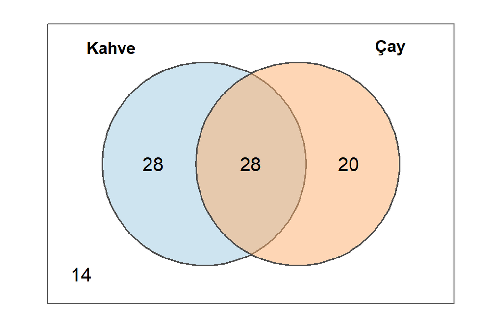

Rassal seçilen bir öğrencinin (üç ondalık):

- yalnızca Kahve içme olasılığı:
- en az birini içme olasılığı:
- hiçbirini içmeme olasılığı:

Toplam öğrenci: $28 + 20 + 28 + 14 = 90$. Olasılık = bölgedeki sayı / 90.

- **Yalnızca Kahve:** dairenin öteki daireyle kesişmeyen bölgesi: $28 / 90 = 0.311$. Olayı parçalara ayırarak da bulunur: bütün Kahve dairesinden ortak bölge çıkarılır, $(56 - 28) / 90 = 28 / 90$.
- **En az biri:** iki dairenin birleşimi, yani üç bölge: $(28 + 28 + 20) / 90 = 76 / 90 = 0.844$
- **Hiçbiri:** dairelerin dışı, birleşimin tümleyeni: $14 / 90 = 0.156$. Denetim: $1 - 0.844 = 0.156$.

Sık yapılan hata: “Kahve içenler” (bütün daire, $56$ kişi) ile “yalnızca Kahve içenler”ı (28 kişi) karıştırmak.

93 üniversite öğrencisine her gün kahve ve çay içip içmedikleri soruldu. Şemadaki sayılar her bölgedeki **öğrenci sayısıdır**; kutunun içindeki ama dairelerin dışındaki sayı ikisinden hiçbirinde yer almayanlardır.

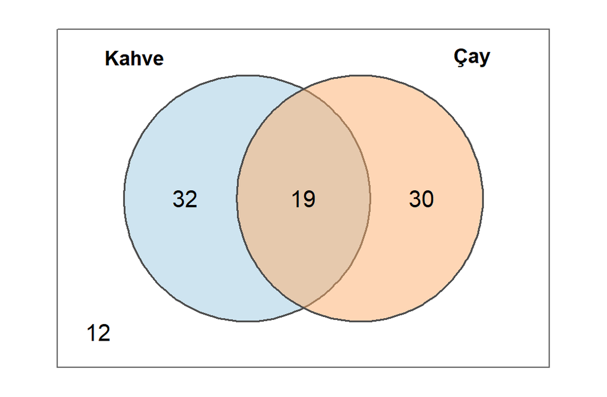

Rassal seçilen bir öğrencinin (üç ondalık):

- yalnızca Kahve içme olasılığı:
- en az birini içme olasılığı:
- hiçbirini içmeme olasılığı:

Toplam öğrenci: $32 + 30 + 19 + 12 = 93$. Olasılık = bölgedeki sayı / 93.

- **Yalnızca Kahve:** dairenin öteki daireyle kesişmeyen bölgesi: $32 / 93 = 0.344$. Olayı parçalara ayırarak da bulunur: bütün Kahve dairesinden ortak bölge çıkarılır, $(51 - 19) / 93 = 32 / 93$.
- **En az biri:** iki dairenin birleşimi, yani üç bölge: $(32 + 19 + 30) / 93 = 81 / 93 = 0.871$
- **Hiçbiri:** dairelerin dışı, birleşimin tümleyeni: $12 / 93 = 0.129$. Denetim: $1 - 0.871 = 0.129$.

Sık yapılan hata: “Kahve içenler” (bütün daire, $51$ kişi) ile “yalnızca Kahve içenler”ı (32 kişi) karıştırmak.

87 üniversite öğrencisine her gün kahve ve çay içip içmedikleri soruldu. Şemadaki sayılar her bölgedeki **öğrenci sayısıdır**; kutunun içindeki ama dairelerin dışındaki sayı ikisinden hiçbirinde yer almayanlardır.

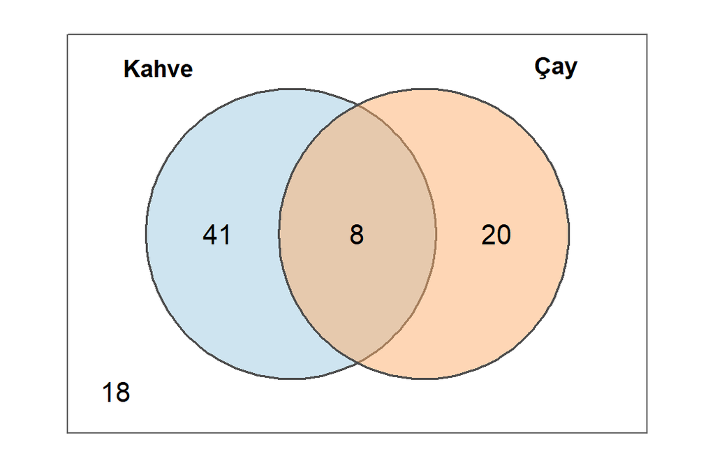

Rassal seçilen bir öğrencinin (üç ondalık):

- yalnızca Kahve içme olasılığı:
- en az birini içme olasılığı:
- hiçbirini içmeme olasılığı:

Toplam öğrenci: $41 + 20 + 8 + 18 = 87$. Olasılık = bölgedeki sayı / 87.

- **Yalnızca Kahve:** dairenin öteki daireyle kesişmeyen bölgesi: $41 / 87 = 0.471$. Olayı parçalara ayırarak da bulunur: bütün Kahve dairesinden ortak bölge çıkarılır, $(49 - 8) / 87 = 41 / 87$.
- **En az biri:** iki dairenin birleşimi, yani üç bölge: $(41 + 8 + 20) / 87 = 69 / 87 = 0.793$
- **Hiçbiri:** dairelerin dışı, birleşimin tümleyeni: $18 / 87 = 0.207$. Denetim: $1 - 0.793 = 0.207$.

Sık yapılan hata: “Kahve içenler” (bütün daire, $49$ kişi) ile “yalnızca Kahve içenler”ı (41 kişi) karıştırmak.

88 üniversite öğrencisine her gün kahve ve çay içip içmedikleri soruldu. Şemadaki sayılar her bölgedeki **öğrenci sayısıdır**; kutunun içindeki ama dairelerin dışındaki sayı ikisinden hiçbirinde yer almayanlardır.

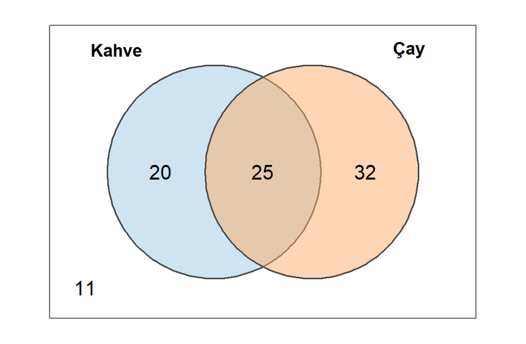

Rassal seçilen bir öğrencinin (üç ondalık):

- yalnızca Kahve içme olasılığı:
- en az birini içme olasılığı:
- hiçbirini içmeme olasılığı:

Toplam öğrenci: $20 + 32 + 25 + 11 = 88$. Olasılık = bölgedeki sayı / 88.

- **Yalnızca Kahve:** dairenin öteki daireyle kesişmeyen bölgesi: $20 / 88 = 0.227$. Olayı parçalara ayırarak da bulunur: bütün Kahve dairesinden ortak bölge çıkarılır, $(45 - 25) / 88 = 20 / 88$.
- **En az biri:** iki dairenin birleşimi, yani üç bölge: $(20 + 25 + 32) / 88 = 77 / 88 = 0.875$
- **Hiçbiri:** dairelerin dışı, birleşimin tümleyeni: $11 / 88 = 0.125$. Denetim: $1 - 0.875 = 0.125$.

Sık yapılan hata: “Kahve içenler” (bütün daire, $45$ kişi) ile “yalnızca Kahve içenler”ı (20 kişi) karıştırmak.

Bir zar, **6** gelme olasılığı öteki sayıların her birininkinin 3 katı olacak biçimde hileli yapılmıştır (öteki beş sayı eşit olasılıklı). Olasılıkları dört ondalıkla veriniz.

- Zarın 5 ya da 6 gelme olasılığı:
- Zarın $3$’ten küçük gelme olasılığı:

Temel sonuçların olasılıkları toplamı 1 olmalıdır. Bir 6 dışındaki sayının olasılığına $q$ diyelim: $5q + 3q = 8q = 1 \Rightarrow q = 1/8$.

| Sonuç | 1 | 2 | 3 | 4 | 5 | 6 |
| --- | --- | --- | --- | --- | --- | --- |
| Olasılık | 1/8 | 1/8 | 1/8 | 1/8 | 1/8 | 3/8 |

- 5 ya da 6 (ayrık sonuçlar): $1/8 + 3/8 = 4/8 = 0.5000$
- $3$’ten küçük, yani $\{1, 2\}$: $2/8 = 0.2500$

Klasik yaklaşımın $N_A/N$ formülü burada **kullanılamaz**, çünkü sonuçlar eşit olasılıklı değil. Olasılığı, olayı oluşturan temel sonuçların olasılıklarını toplayarak buluruz.

Bir zar, **çift** sayıların her birinin gelme olasılığı **tek** sayıların her birininkinin 2 katı olacak biçimde hileli yapılmıştır. Olasılıkları dört ondalıkla veriniz.

- Zarın 5 ya da 6 gelme olasılığı:
- Zarın $4$’ten küçük gelme olasılığı:

Temel sonuçların olasılıkları toplamı 1 olmalıdır. Bir tek sayının olasılığına $q$ diyelim: $3q + 3(2q) = 9q = 1 \Rightarrow q = 1/9$.

| Sonuç | 1 | 2 | 3 | 4 | 5 | 6 |
| --- | --- | --- | --- | --- | --- | --- |
| Olasılık | 1/9 | 2/9 | 1/9 | 2/9 | 1/9 | 2/9 |

- 5 ya da 6 (ayrık sonuçlar): $1/9 + 2/9 = 3/9 = 0.3333$
- $4$’ten küçük, yani $\{1, 2, 3\}$: $4/9 = 0.4444$

Klasik yaklaşımın $N_A/N$ formülü burada **kullanılamaz**, çünkü sonuçlar eşit olasılıklı değil. Olasılığı, olayı oluşturan temel sonuçların olasılıklarını toplayarak buluruz.

Bir zar, **çift** sayıların her birinin gelme olasılığı **tek** sayıların her birininkinin 3 katı olacak biçimde hileli yapılmıştır. Olasılıkları dört ondalıkla veriniz.

- Zarın 5 ya da 6 gelme olasılığı:
- Zarın $4$’ten küçük gelme olasılığı:

Temel sonuçların olasılıkları toplamı 1 olmalıdır. Bir tek sayının olasılığına $q$ diyelim: $3q + 3(3q) = 12q = 1 \Rightarrow q = 1/12$.

| Sonuç | 1 | 2 | 3 | 4 | 5 | 6 |
| --- | --- | --- | --- | --- | --- | --- |
| Olasılık | 1/12 | 3/12 | 1/12 | 3/12 | 1/12 | 3/12 |

- 5 ya da 6 (ayrık sonuçlar): $1/12 + 3/12 = 4/12 = 0.3333$
- $4$’ten küçük, yani $\{1, 2, 3\}$: $5/12 = 0.4167$

Klasik yaklaşımın $N_A/N$ formülü burada **kullanılamaz**, çünkü sonuçlar eşit olasılıklı değil. Olasılığı, olayı oluşturan temel sonuçların olasılıklarını toplayarak buluruz.

Bir zar, **çift** sayıların her birinin gelme olasılığı **tek** sayıların her birininkinin 2 katı olacak biçimde hileli yapılmıştır. Olasılıkları dört ondalıkla veriniz.

- Zarın 5 ya da 6 gelme olasılığı:
- Zarın $4$’ten küçük gelme olasılığı:

Temel sonuçların olasılıkları toplamı 1 olmalıdır. Bir tek sayının olasılığına $q$ diyelim: $3q + 3(2q) = 9q = 1 \Rightarrow q = 1/9$.

| Sonuç | 1 | 2 | 3 | 4 | 5 | 6 |
| --- | --- | --- | --- | --- | --- | --- |
| Olasılık | 1/9 | 2/9 | 1/9 | 2/9 | 1/9 | 2/9 |

- 5 ya da 6 (ayrık sonuçlar): $1/9 + 2/9 = 3/9 = 0.3333$
- $4$’ten küçük, yani $\{1, 2, 3\}$: $4/9 = 0.4444$

Klasik yaklaşımın $N_A/N$ formülü burada **kullanılamaz**, çünkü sonuçlar eşit olasılıklı değil. Olasılığı, olayı oluşturan temel sonuçların olasılıklarını toplayarak buluruz.

2 hilesiz zar atılıyor. Dört ondalıkla:

- $\mathbb{P}(\text{hiçbir zarın 6 gelmemesi})$:
- $\mathbb{P}(\text{en az bir zarın 6 gelmesi})$:

Çarpım kuralıyla eşit olasılıklı bütün sonuçların sayısı $6^{2} = 36$.

“Hiçbir zarın 6 gelmemesi” için her zarda 6 dışındaki 5 sonuçtan biri gelmeli: $5^{2} = 25$ sonuç.

$$\mathbb{P}(\text{hiç}) = \frac{25}{36} = 0.6944$$

“En az bir” olayı; bir, iki, … tane gibi birçok ayrık durumu kapsar. Tümleyeni ise tek bir durumdur: hiç. Tümleyen kuralıyla:

$$\mathbb{P}(\text{en az bir}) = 1 - \mathbb{P}(\text{hiç}) = 1 - 0.6944 = 0.3056$$

3 haneli bir kilit şifresi (her hane 0-9) rassal olarak ayarlanıyor; bütün şifreler eşit olasılıklı. Dört ondalıkla:

- $\mathbb{P}(\text{şifrede hiç 0 bulunmaması})$:
- $\mathbb{P}(\text{şifrede en az bir 0 bulunması})$:

Çarpım kuralıyla eşit olasılıklı bütün sonuçların sayısı $10^{3} = 1000$.

“Şifrede hiç 0 bulunmaması” için her hanede 0 dışındaki 9 rakamdan biri gelmeli: $9^{3} = 729$ sonuç.

$$\mathbb{P}(\text{hiç}) = \frac{729}{1000} = 0.7290$$

“En az bir” olayı; bir, iki, … tane gibi birçok ayrık durumu kapsar. Tümleyeni ise tek bir durumdur: hiç. Tümleyen kuralıyla:

$$\mathbb{P}(\text{en az bir}) = 1 - \mathbb{P}(\text{hiç}) = 1 - 0.7290 = 0.2710$$

3 haneli bir kilit şifresi (her hane 0-9) rassal olarak ayarlanıyor; bütün şifreler eşit olasılıklı. Dört ondalıkla:

- $\mathbb{P}(\text{şifrede hiç 0 bulunmaması})$:
- $\mathbb{P}(\text{şifrede en az bir 0 bulunması})$:

Çarpım kuralıyla eşit olasılıklı bütün sonuçların sayısı $10^{3} = 1000$.

“Şifrede hiç 0 bulunmaması” için her hanede 0 dışındaki 9 rakamdan biri gelmeli: $9^{3} = 729$ sonuç.

$$\mathbb{P}(\text{hiç}) = \frac{729}{1000} = 0.7290$$

“En az bir” olayı; bir, iki, … tane gibi birçok ayrık durumu kapsar. Tümleyeni ise tek bir durumdur: hiç. Tümleyen kuralıyla:

$$\mathbb{P}(\text{en az bir}) = 1 - \mathbb{P}(\text{hiç}) = 1 - 0.7290 = 0.2710$$

3 hilesiz zar atılıyor. Dört ondalıkla:

- $\mathbb{P}(\text{hiçbir zarın 6 gelmemesi})$:
- $\mathbb{P}(\text{en az bir zarın 6 gelmesi})$:

Çarpım kuralıyla eşit olasılıklı bütün sonuçların sayısı $6^{3} = 216$.

“Hiçbir zarın 6 gelmemesi” için her zarda 6 dışındaki 5 sonuçtan biri gelmeli: $5^{3} = 125$ sonuç.

$$\mathbb{P}(\text{hiç}) = \frac{125}{216} = 0.5787$$

“En az bir” olayı; bir, iki, … tane gibi birçok ayrık durumu kapsar. Tümleyeni ise tek bir durumdur: hiç. Tümleyen kuralıyla:

$$\mathbb{P}(\text{en az bir}) = 1 - \mathbb{P}(\text{hiç}) = 1 - 0.5787 = 0.4213$$

### Sayma

8 soruluk bir testte her sorunun 5 şıkkı var. Bir öğrenci kaç farklı cevap kâğıdı doldurabilir?

- Hangi sayma kuralı?
- Sonuç:

İki soru sorun: **Sıra önemli mi?** (Farklı sıralanışlar farklı sonuç mu sayılıyor?) **Aynı öğe birden fazla seçilebilir mi?**

Sıra önemli (hanelerin/soruların yeri belli) ve her seçimde bütün seçenekler yeniden kullanılabiliyor: çarpım kuralı her adımda aynı sayıyı verir.

$$5^{8} = 390625$$

5 soruluk bir testte her sorunun 5 şıkkı var. Bir öğrenci kaç farklı cevap kâğıdı doldurabilir?

- Hangi sayma kuralı?
- Sonuç:

İki soru sorun: **Sıra önemli mi?** (Farklı sıralanışlar farklı sonuç mu sayılıyor?) **Aynı öğe birden fazla seçilebilir mi?**

Sıra önemli (hanelerin/soruların yeri belli) ve her seçimde bütün seçenekler yeniden kullanılabiliyor: çarpım kuralı her adımda aynı sayıyı verir.

$$5^{5} = 3125$$

Bir rafa 9 farklı kitaptan 3 tanesi yan yana dizilecek. Kaç farklı diziliş vardır?

- Hangi sayma kuralı?
- Sonuç:

İki soru sorun: **Sıra önemli mi?** (Farklı sıralanışlar farklı sonuç mu sayılıyor?) **Aynı öğe birden fazla seçilebilir mi?**

Sıra önemli (birinci ile ikinci, başkan ile sayman farklı) ve bir kişi/nesne bir kez seçilebiliyor: permütasyon.

$$P^{9}_{3} = \frac{9!}{6!} = 9 \times 8 \times 7 = 504$$

Bir pizzacıda 10 malzeme var. 3 farklı malzemeli bir pizza kaç farklı biçimde hazırlanabilir?

- Hangi sayma kuralı?
- Sonuç:

İki soru sorun: **Sıra önemli mi?** (Farklı sıralanışlar farklı sonuç mu sayılıyor?) **Aynı öğe birden fazla seçilebilir mi?**

Yalnızca kimlerin/nelerin seçildiği önemli, sırası değil; bir öğe bir kez seçilebiliyor: kombinasyon.

$$\binom{10}{3} = \frac{10!}{3!\,7!} = 120$$

Aynı grubun sıralı hâlleri sayılsaydı permütasyon $P^{10}_{3} = 720$ olurdu; her grup $3! = 6$ farklı biçimde sıralanabildiği için kombinasyon permütasyonun $3!$’e bölünmüşüdür.

Bir koşuda 8 yarışmacı var. İlk 3 sıra (birinci, ikinci, …) kaç farklı biçimde oluşabilir?

- Hangi sayma kuralı?
- Sonuç:

İki soru sorun: **Sıra önemli mi?** (Farklı sıralanışlar farklı sonuç mu sayılıyor?) **Aynı öğe birden fazla seçilebilir mi?**

Sıra önemli (birinci ile ikinci, başkan ile sayman farklı) ve bir kişi/nesne bir kez seçilebiliyor: permütasyon.

$$P^{8}_{3} = \frac{8!}{5!} = 8 \times 7 \times 6 = 336$$

Bir koşuda 11 yarışmacı var. İlk 3 sıra (birinci, ikinci, …) kaç farklı biçimde oluşabilir?

- Hangi sayma kuralı?
- Sonuç:

İki soru sorun: **Sıra önemli mi?** (Farklı sıralanışlar farklı sonuç mu sayılıyor?) **Aynı öğe birden fazla seçilebilir mi?**

Sıra önemli (birinci ile ikinci, başkan ile sayman farklı) ve bir kişi/nesne bir kez seçilebiliyor: permütasyon.

$$P^{11}_{3} = \frac{11!}{8!} = 11 \times 10 \times 9 = 990$$

16 kişilik bir bölümden 3 kişilik bir çalışma grubu (görev dağılımı yok) seçilecek. Kaç farklı grup kurulabilir?

- Hangi sayma kuralı?
- Sonuç:

İki soru sorun: **Sıra önemli mi?** (Farklı sıralanışlar farklı sonuç mu sayılıyor?) **Aynı öğe birden fazla seçilebilir mi?**

Yalnızca kimlerin/nelerin seçildiği önemli, sırası değil; bir öğe bir kez seçilebiliyor: kombinasyon.

$$\binom{16}{3} = \frac{16!}{3!\,13!} = 560$$

Aynı grubun sıralı hâlleri sayılsaydı permütasyon $P^{16}_{3} = 3360$ olurdu; her grup $3! = 6$ farklı biçimde sıralanabildiği için kombinasyon permütasyonun $3!$’e bölünmüşüdür.

19 kişilik bir dernekten başkan, başkan yardımcısı ve sayman seçilecek (bir kişi tek görev alır). Kaç farklı yönetim oluşur?

- Hangi sayma kuralı?
- Sonuç:

İki soru sorun: **Sıra önemli mi?** (Farklı sıralanışlar farklı sonuç mu sayılıyor?) **Aynı öğe birden fazla seçilebilir mi?**

Sıra önemli (birinci ile ikinci, başkan ile sayman farklı) ve bir kişi/nesne bir kez seçilebiliyor: permütasyon.

$$P^{19}_{3} = \frac{19!}{16!} = 19 \times 18 \times 17 = 5814$$

$1,\ 2,\ 4,\ 5,\ 7$ rakamları kullanılarak üç basamaklı sayılar oluşturulacaktır.

- Rakamlar **tekrar etmeden** kaç sayı oluşturulabilir?
- Rakamlar **tekrar edebilirse** kaç sayı oluşturulabilir?
- Rakamlar tekrar etmeden kaç **çift** sayı oluşturulabilir?

Basamakları soldan sağa doldurup çarpım kuralını uygulayın (5 rakam var).

- **Tekrarsız:** $5 \times 4 \times 3 = 60$ (permütasyon $P^{5}_3$)
- **Tekrarlı:** her basamakta 5 seçenek: $5^3 = 125$
- **Tekrarsız çift:** önce **kısıtlı** basamağı doldurun. Birler basamağı çift olmalı: 2 seçenek ($2, 4$). Kalan iki basamağa kalan rakamlardan: $4 \times 3$. Toplam: $2 \times 4 \times 3 = 24$

Kısıtlı adımla başlamak işi kolaylaştırır; soldan başlasaydık birler basamağına kaç çift rakam kaldığı önceki seçimlere bağlı olurdu.

$1,\ 4,\ 6,\ 8,\ 9$ rakamları kullanılarak üç basamaklı sayılar oluşturulacaktır.

- Rakamlar **tekrar etmeden** kaç sayı oluşturulabilir?
- Rakamlar **tekrar edebilirse** kaç sayı oluşturulabilir?
- Rakamlar tekrar etmeden kaç **çift** sayı oluşturulabilir?

Basamakları soldan sağa doldurup çarpım kuralını uygulayın (5 rakam var).

- **Tekrarsız:** $5 \times 4 \times 3 = 60$ (permütasyon $P^{5}_3$)
- **Tekrarlı:** her basamakta 5 seçenek: $5^3 = 125$
- **Tekrarsız çift:** önce **kısıtlı** basamağı doldurun. Birler basamağı çift olmalı: 3 seçenek ($4, 6, 8$). Kalan iki basamağa kalan rakamlardan: $4 \times 3$. Toplam: $3 \times 4 \times 3 = 36$

Kısıtlı adımla başlamak işi kolaylaştırır; soldan başlasaydık birler basamağına kaç çift rakam kaldığı önceki seçimlere bağlı olurdu.

$1,\ 3,\ 4,\ 6,\ 8,\ 9$ rakamları kullanılarak üç basamaklı sayılar oluşturulacaktır.

- Rakamlar **tekrar etmeden** kaç sayı oluşturulabilir?
- Rakamlar **tekrar edebilirse** kaç sayı oluşturulabilir?
- Rakamlar tekrar etmeden kaç **çift** sayı oluşturulabilir?

Basamakları soldan sağa doldurup çarpım kuralını uygulayın (6 rakam var).

- **Tekrarsız:** $6 \times 5 \times 4 = 120$ (permütasyon $P^{6}_3$)
- **Tekrarlı:** her basamakta 6 seçenek: $6^3 = 216$
- **Tekrarsız çift:** önce **kısıtlı** basamağı doldurun. Birler basamağı çift olmalı: 3 seçenek ($4, 6, 8$). Kalan iki basamağa kalan rakamlardan: $5 \times 4$. Toplam: $3 \times 5 \times 4 = 60$

Kısıtlı adımla başlamak işi kolaylaştırır; soldan başlasaydık birler basamağına kaç çift rakam kaldığı önceki seçimlere bağlı olurdu.

$1,\ 2,\ 3,\ 7,\ 9$ rakamları kullanılarak üç basamaklı sayılar oluşturulacaktır.

- Rakamlar **tekrar etmeden** kaç sayı oluşturulabilir?
- Rakamlar **tekrar edebilirse** kaç sayı oluşturulabilir?
- Rakamlar tekrar etmeden kaç **çift** sayı oluşturulabilir?

Basamakları soldan sağa doldurup çarpım kuralını uygulayın (5 rakam var).

- **Tekrarsız:** $5 \times 4 \times 3 = 60$ (permütasyon $P^{5}_3$)
- **Tekrarlı:** her basamakta 5 seçenek: $5^3 = 125$
- **Tekrarsız çift:** önce **kısıtlı** basamağı doldurun. Birler basamağı çift olmalı: 1 seçenek ($2$). Kalan iki basamağa kalan rakamlardan: $4 \times 3$. Toplam: $1 \times 4 \times 3 = 12$

Kısıtlı adımla başlamak işi kolaylaştırır; soldan başlasaydık birler basamağına kaç çift rakam kaldığı önceki seçimlere bağlı olurdu.

8 erkek ve 4 kadın aday arasından 4 kişilik bir kurul rassal olarak seçiliyor. Dört ondalıkla:

- Seçilenler arasında hiç kadın olmaması:
- En az bir kadın olması:
- Tam 2 kadın olması:

Bütün seçimler eşit olasılıklıdır; sıra önemsiz olduğu için kombinasyonla sayılır:

$$\text{bütün seçimler} = \binom{12}{4} = 495$$

- **Hiç kadın yok:** 4 kişinin/parçanın hepsi 8 erkek arasından: $\binom{8}{4} / 495 = 70 / 495 = 0.1414$
- **En az bir:** tümleyenden: $1 - 0.1414 = 0.8586$
- **Tam 2:** 2 tane 4 kadın arasından, kalan 2 tane 8 erkek arasından; çarpım kuralı: $\binom{4}{2}\binom{8}{2} / 495 = 6 \times 28 / 495 = 0.3394$

Denetim: kadın sayısının 0, 1, …, 4 olduğu durumların sayıları toplamı 495 eder: $70 + 224 + 168 + 32 + 1 = 495$.

5 erkek ve 5 kadın aday arasından 3 kişilik bir kurul rassal olarak seçiliyor. Dört ondalıkla:

- Seçilenler arasında hiç kadın olmaması:
- En az bir kadın olması:
- Tam 1 kadın olması:

Bütün seçimler eşit olasılıklıdır; sıra önemsiz olduğu için kombinasyonla sayılır:

$$\text{bütün seçimler} = \binom{10}{3} = 120$$

- **Hiç kadın yok:** 3 kişinin/parçanın hepsi 5 erkek arasından: $\binom{5}{3} / 120 = 10 / 120 = 0.0833$
- **En az bir:** tümleyenden: $1 - 0.0833 = 0.9167$
- **Tam 1:** 1 tane 5 kadın arasından, kalan 2 tane 5 erkek arasından; çarpım kuralı: $\binom{5}{1}\binom{5}{2} / 120 = 5 \times 10 / 120 = 0.4167$

Denetim: kadın sayısının 0, 1, …, 3 olduğu durumların sayıları toplamı 120 eder: $10 + 50 + 50 + 10 = 120$.

Bir partide 11 kusursuz ve 2 kusurlu yedek parça var. Bir fabrika partiden rassal olarak 4 parça satın alıyor. Dört ondalıkla:

- Seçilenler arasında hiç kusurlu olmaması:
- En az bir kusurlu olması:
- Tam 2 kusurlu olması:

Bütün seçimler eşit olasılıklıdır; sıra önemsiz olduğu için kombinasyonla sayılır:

$$\text{bütün seçimler} = \binom{13}{4} = 715$$

- **Hiç kusurlu yok:** 4 kişinin/parçanın hepsi 11 kusursuz arasından: $\binom{11}{4} / 715 = 330 / 715 = 0.4615$
- **En az bir:** tümleyenden: $1 - 0.4615 = 0.5385$
- **Tam 2:** 2 tane 2 kusurlu arasından, kalan 2 tane 11 kusursuz arasından; çarpım kuralı: $\binom{2}{2}\binom{11}{2} / 715 = 1 \times 55 / 715 = 0.0769$

Denetim: kusurlu sayısının 0, 1, …, 2 olduğu durumların sayıları toplamı 715 eder: $330 + 330 + 55 = 715$.

Bir partide 10 kusursuz ve 3 kusurlu yedek parça var. Bir fabrika partiden rassal olarak 3 parça satın alıyor. Dört ondalıkla:

- Seçilenler arasında hiç kusurlu olmaması:
- En az bir kusurlu olması:
- Tam 2 kusurlu olması:

Bütün seçimler eşit olasılıklıdır; sıra önemsiz olduğu için kombinasyonla sayılır:

$$\text{bütün seçimler} = \binom{13}{3} = 286$$

- **Hiç kusurlu yok:** 3 kişinin/parçanın hepsi 10 kusursuz arasından: $\binom{10}{3} / 286 = 120 / 286 = 0.4196$
- **En az bir:** tümleyenden: $1 - 0.4196 = 0.5804$
- **Tam 2:** 2 tane 3 kusurlu arasından, kalan 1 tane 10 kusursuz arasından; çarpım kuralı: $\binom{3}{2}\binom{10}{1} / 286 = 3 \times 10 / 286 = 0.1049$

Denetim: kusurlu sayısının 0, 1, …, 3 olduğu durumların sayıları toplamı 286 eder: $120 + 135 + 30 + 1 = 286$.

Hilesiz bir para 5 kez atılıyor.

- Tam 3 tura içeren kaç farklı dizilim vardır?
- $\mathbb{P}(\text{tam 3 tura})$ (dört ondalık):

Bütün dizilimler (ör. TYTYT) eşit olasılıklıdır; toplam $2^{5} = 32$ dizilim var, her birinin olasılığı $1/32$.

3 tane T içeren dizilimler, 5 yerden 3 tanesinin T için **seçilmesiyle** oluşur; sıra önemsiz:

$$\binom{5}{3} = 10$$

Bu dizilimler ayrıktır; olasılıkları toplanır:

$$\mathbb{P}(\text{tam 3 tura}) = \frac{10}{32} = 0.3125$$

Olasılık $p$ ile genelleştirilirse $\binom{n}{k} p^k (1 - p)^{n - k}$ olur; bu formülü **binom dağılımı** adıyla kesikli rassal değişkenlerde göreceğiz.

Hilesiz bir para 10 kez atılıyor.

- Tam 7 tura içeren kaç farklı dizilim vardır?
- $\mathbb{P}(\text{tam 7 tura})$ (dört ondalık):

Bütün dizilimler (ör. YTTTTYYTTT) eşit olasılıklıdır; toplam $2^{10} = 1024$ dizilim var, her birinin olasılığı $1/1024$.

7 tane T içeren dizilimler, 10 yerden 7 tanesinin T için **seçilmesiyle** oluşur; sıra önemsiz:

$$\binom{10}{7} = 120$$

Bu dizilimler ayrıktır; olasılıkları toplanır:

$$\mathbb{P}(\text{tam 7 tura}) = \frac{120}{1024} = 0.1172$$

Olasılık $p$ ile genelleştirilirse $\binom{n}{k} p^k (1 - p)^{n - k}$ olur; bu formülü **binom dağılımı** adıyla kesikli rassal değişkenlerde göreceğiz.

Hilesiz bir para 10 kez atılıyor.

- Tam 6 tura içeren kaç farklı dizilim vardır?
- $\mathbb{P}(\text{tam 6 tura})$ (dört ondalık):

Bütün dizilimler (ör. TYYTTTYTTY) eşit olasılıklıdır; toplam $2^{10} = 1024$ dizilim var, her birinin olasılığı $1/1024$.

6 tane T içeren dizilimler, 10 yerden 6 tanesinin T için **seçilmesiyle** oluşur; sıra önemsiz:

$$\binom{10}{6} = 210$$

Bu dizilimler ayrıktır; olasılıkları toplanır:

$$\mathbb{P}(\text{tam 6 tura}) = \frac{210}{1024} = 0.2051$$

Olasılık $p$ ile genelleştirilirse $\binom{n}{k} p^k (1 - p)^{n - k}$ olur; bu formülü **binom dağılımı** adıyla kesikli rassal değişkenlerde göreceğiz.

Hilesiz bir para 10 kez atılıyor.

- Tam 2 tura içeren kaç farklı dizilim vardır?
- $\mathbb{P}(\text{tam 2 tura})$ (dört ondalık):

Bütün dizilimler (ör. YYTYYTYYYY) eşit olasılıklıdır; toplam $2^{10} = 1024$ dizilim var, her birinin olasılığı $1/1024$.

2 tane T içeren dizilimler, 10 yerden 2 tanesinin T için **seçilmesiyle** oluşur; sıra önemsiz:

$$\binom{10}{2} = 45$$

Bu dizilimler ayrıktır; olasılıkları toplanır:

$$\mathbb{P}(\text{tam 2 tura}) = \frac{45}{1024} = 0.0439$$

Olasılık $p$ ile genelleştirilirse $\binom{n}{k} p^k (1 - p)^{n - k}$ olur; bu formülü **binom dağılımı** adıyla kesikli rassal değişkenlerde göreceğiz.

Rassal seçilen 5 kişinin doğdukları haftanın günü (7 gün eşit olasılıklı) gözleniyor. Dört ondalıkla:

- Hiçbir ikisinin aynı günde doğmamış olması:
- En az ikisinin haftanın aynı gününde doğmuş olması:

Bütün sonuçlar: her kişi için 7 seçenek, $7^{5} = 16807$.

**Hiç eşleşme yok:** birinci kişi 7 seçeneğin herhangi birini, ikinci kişi kalan 6 seçenekten birini, … alır:

$$\mathbb{P}(\text{eşleşme yok}) = \frac{7 \times 6 \times 5 \times 4 \times 3}{7^{5}} = \frac{2520}{16807} = 0.1499$$

**En az bir eşleşme:** “en az iki kişi aynı” olayı birçok ayrık durumu kapsar; tümleyeni tek durumdur:

$$1 - 0.1499 = 0.8501$$

Doğum günü problemiyle aynı mantık: seçenek sayısı azaldıkça eşleşme çok çabuk olası hâle gelir.

Rassal seçilen 6 kişinin doğdukları ay (12 ay eşit olasılıklı) gözleniyor. Dört ondalıkla:

- Hiçbir ikisinin aynı ayda doğmamış olması:
- En az ikisinin aynı ayda doğmuş olması:

Bütün sonuçlar: her kişi için 12 seçenek, $12^{6} = 2985984$.

**Hiç eşleşme yok:** birinci kişi 12 seçeneğin herhangi birini, ikinci kişi kalan 11 seçenekten birini, … alır:

$$\mathbb{P}(\text{eşleşme yok}) = \frac{12 \times 11 \times 10 \times 9 \times 8 \times 7}{12^{6}} = \frac{665280}{2985984} = 0.2228$$

**En az bir eşleşme:** “en az iki kişi aynı” olayı birçok ayrık durumu kapsar; tümleyeni tek durumdur:

$$1 - 0.2228 = 0.7772$$

Doğum günü problemiyle aynı mantık: seçenek sayısı azaldıkça eşleşme çok çabuk olası hâle gelir.

Rassal seçilen 5 kişinin doğdukları haftanın günü (7 gün eşit olasılıklı) gözleniyor. Dört ondalıkla:

- Hiçbir ikisinin aynı günde doğmamış olması:
- En az ikisinin haftanın aynı gününde doğmuş olması:

Bütün sonuçlar: her kişi için 7 seçenek, $7^{5} = 16807$.

**Hiç eşleşme yok:** birinci kişi 7 seçeneğin herhangi birini, ikinci kişi kalan 6 seçenekten birini, … alır:

$$\mathbb{P}(\text{eşleşme yok}) = \frac{7 \times 6 \times 5 \times 4 \times 3}{7^{5}} = \frac{2520}{16807} = 0.1499$$

**En az bir eşleşme:** “en az iki kişi aynı” olayı birçok ayrık durumu kapsar; tümleyeni tek durumdur:

$$1 - 0.1499 = 0.8501$$

Doğum günü problemiyle aynı mantık: seçenek sayısı azaldıkça eşleşme çok çabuk olası hâle gelir.

Rassal seçilen 3 kişinin doğdukları haftanın günü (7 gün eşit olasılıklı) gözleniyor. Dört ondalıkla:

- Hiçbir ikisinin aynı günde doğmamış olması:
- En az ikisinin haftanın aynı gününde doğmuş olması:

Bütün sonuçlar: her kişi için 7 seçenek, $7^{3} = 343$.

**Hiç eşleşme yok:** birinci kişi 7 seçeneğin herhangi birini, ikinci kişi kalan 6 seçenekten birini, … alır:

$$\mathbb{P}(\text{eşleşme yok}) = \frac{7 \times 6 \times 5}{7^{3}} = \frac{210}{343} = 0.6122$$

**En az bir eşleşme:** “en az iki kişi aynı” olayı birçok ayrık durumu kapsar; tümleyeni tek durumdur:

$$1 - 0.6122 = 0.3878$$

Doğum günü problemiyle aynı mantık: seçenek sayısı azaldıkça eşleşme çok çabuk olası hâle gelir.

## Yanılgıları yakalama

Aşağıdaki ifadelerden **doğru olanların hepsini** işaretleyiniz.

“En az bir” türündeki olasılıkları tümleyenden hesaplamak çoğu zaman daha kolaydır.Her $A$ olayı için $\mathbb{P}(\bar{A}) = 1 - \mathbb{P}(A)$ olur.İki zar atıldığında (1, 2) ile (2, 1) aynı sonuç sayılır, bu yüzden örneklem uzayında 21 eşit olasılıklı sonuç vardır.Hilesiz bir parayı 10 kez atıp 7 tura gözlersek tura olasılığı 0.7’dir.Borsa yarın ya artışla ya düşüşle kapanacağına göre artışla kapanma olasılığı 1/2’dir.

Her ifadenin değerlendirmesi aşağıdadır. Yanlış bir ifadeyi işaretlediyseniz neden yanlış olduğunu kendi cümlelerinizle yazmayı deneyin.

- **Doğru.** $\mathbb{P}(\text{en az bir}) = 1 - \mathbb{P}(\text{hiç})$; “hiç” tek bir durumdur.
- **Doğru.** $A$ ile $\bar{A}$ ayrık ve bütünü kapsayıcıdır; olasılıkları toplamı 1’dir.
- **Yanlış.** Zarlar ayırt edilebilir; 36 sıralı ikili eşit olasılıklıdır. 21 sırasız sonuç eşit olasılıklı değildir: {1, 2} iki, {1, 1} tek ikiliyle gelir.
- **Yanlış.** Az sayıda denemede göreli sıklık olasılıktan epeyce sapabilir; ancak deneme sayısı çok büyüdükçe olasılığa yaklaşır.
- **Yanlış.** $N_A/N$ yalnızca sonuçlar eşit olasılıklıysa geçerlidir; iki sonuç olması eşit olasılıklı oldukları anlamına gelmez.

Aşağıdaki ifadelerden **doğru olanların hepsini** işaretleyiniz.

Her $A$ olayı için $\mathbb{P}(\bar{A}) = 1 - \mathbb{P}(A)$ olur.Her $A$ ve $B$ olayı için $\mathbb{P}(A \cup B) = \mathbb{P}(A) + \mathbb{P}(B)$ olur.Ayrık iki olayın birleşimi her zaman örneklem uzayının tamamıdır.“En az bir” türündeki olasılıkları tümleyenden hesaplamak çoğu zaman daha kolaydır.Öznel olasılık yalnızca tekrarlanamayan olaylara (örneğin tek bir maçın sonucuna) atanabilir.

Her ifadenin değerlendirmesi aşağıdadır. Yanlış bir ifadeyi işaretlediyseniz neden yanlış olduğunu kendi cümlelerinizle yazmayı deneyin.

- **Doğru.** $A$ ile $\bar{A}$ ayrık ve bütünü kapsayıcıdır; olasılıkları toplamı 1’dir.
- **Yanlış.** Bu yalnızca ayrık olaylar için doğrudur; genel kuralda $\mathbb{P}(A \cap B)$ çıkarılır.
- **Yanlış.** Bu bütünü kapsayıcılıktır ve ayrıklıktan farklıdır; örneğin zarda $\{1, 2\}$ ile $\{5, 6\}$ ayrıktır ama 3 ve 4’ü kapsamaz.
- **Doğru.** $\mathbb{P}(\text{en az bir}) = 1 - \mathbb{P}(\text{hiç})$; “hiç” tek bir durumdur.
- **Yanlış.** Öznel olasılık bir inanç derecesidir ve tekrarlanan olaylara da atanabilir: bir yatırımcının yarın borsanın artışla kapanmasına ya da bir mühendisin yeni bir makinenin kusurlu ürün oranına verdiği olasılık gibi.

Aşağıdaki ifadelerden **doğru olanların hepsini** işaretleyiniz.

$0! = 1$ kabul edilir.Öznel olasılık yalnızca tekrarlanamayan olaylara (örneğin tek bir maçın sonucuna) atanabilir.İki zar atıldığında (1, 2) ile (2, 1) aynı sonuç sayılır, bu yüzden örneklem uzayında 21 eşit olasılıklı sonuç vardır.Aynı $n$ ve $r$ için permütasyon sayısı kombinasyon sayısından küçük olamaz.Her $A$ ve $B$ olayı için $\mathbb{P}(A \cup B) = \mathbb{P}(A) + \mathbb{P}(B)$ olur.

Her ifadenin değerlendirmesi aşağıdadır. Yanlış bir ifadeyi işaretlediyseniz neden yanlış olduğunu kendi cümlelerinizle yazmayı deneyin.

- **Doğru.** Böylece $\binom{n}{0} = \binom{n}{n} = 1$ gibi formüller tutarlı olur: $n$ nesneden hiçbirini seçmenin tek yolu vardır.
- **Yanlış.** Öznel olasılık bir inanç derecesidir ve tekrarlanan olaylara da atanabilir: bir yatırımcının yarın borsanın artışla kapanmasına ya da bir mühendisin yeni bir makinenin kusurlu ürün oranına verdiği olasılık gibi.
- **Yanlış.** Zarlar ayırt edilebilir; 36 sıralı ikili eşit olasılıklıdır. 21 sırasız sonuç eşit olasılıklı değildir: {1, 2} iki, {1, 1} tek ikiliyle gelir.
- **Doğru.** Her kombinasyon $r!$ farklı biçimde sıralanır: $P^n_r = r! \binom{n}{r}$.
- **Yanlış.** Bu yalnızca ayrık olaylar için doğrudur; genel kuralda $\mathbb{P}(A \cap B)$ çıkarılır.

Aşağıdaki ifadelerden **doğru olanların hepsini** işaretleyiniz.

$0! = 1$ kabul edilir.Her $A$ olayı için $\mathbb{P}(\bar{A}) = 1 - \mathbb{P}(A)$ olur.İki zar atıldığında (1, 2) ile (2, 1) aynı sonuç sayılır, bu yüzden örneklem uzayında 21 eşit olasılıklı sonuç vardır.“En az bir” türündeki olasılıkları tümleyenden hesaplamak çoğu zaman daha kolaydır.Ayrık iki olayın birleşimi her zaman örneklem uzayının tamamıdır.

Her ifadenin değerlendirmesi aşağıdadır. Yanlış bir ifadeyi işaretlediyseniz neden yanlış olduğunu kendi cümlelerinizle yazmayı deneyin.

- **Doğru.** Böylece $\binom{n}{0} = \binom{n}{n} = 1$ gibi formüller tutarlı olur: $n$ nesneden hiçbirini seçmenin tek yolu vardır.
- **Doğru.** $A$ ile $\bar{A}$ ayrık ve bütünü kapsayıcıdır; olasılıkları toplamı 1’dir.
- **Yanlış.** Zarlar ayırt edilebilir; 36 sıralı ikili eşit olasılıklıdır. 21 sırasız sonuç eşit olasılıklı değildir: {1, 2} iki, {1, 1} tek ikiliyle gelir.
- **Doğru.** $\mathbb{P}(\text{en az bir}) = 1 - \mathbb{P}(\text{hiç})$; “hiç” tek bir durumdur.
- **Yanlış.** Bu bütünü kapsayıcılıktır ve ayrıklıktan farklıdır; örneğin zarda $\{1, 2\}$ ile $\{5, 6\}$ ayrıktır ama 3 ve 4’ü kapsamaz.

Aşağıdaki ifadelerden **doğru olanların hepsini** işaretleyiniz.

Ayrık iki olay için $\mathbb{P}(A \cup B) = \mathbb{P}(A) + \mathbb{P}(B)$ olur.Borsa yarın ya artışla ya düşüşle kapanacağına göre artışla kapanma olasılığı 1/2’dir.Öznel, göreli sıklık ve klasik yaklaşımların üçü de aynı olasılık kurallarına uyar.Ayrık iki olayın birleşimi her zaman örneklem uzayının tamamıdır.“En az bir” türündeki olasılıkları tümleyenden hesaplamak çoğu zaman daha kolaydır.

Her ifadenin değerlendirmesi aşağıdadır. Yanlış bir ifadeyi işaretlediyseniz neden yanlış olduğunu kendi cümlelerinizle yazmayı deneyin.

- **Doğru.** Ayrık olaylarda kesişimin olasılığı sıfırdır; toplama kuralındaki çıkarılan terim kalkar.
- **Yanlış.** $N_A/N$ yalnızca sonuçlar eşit olasılıklıysa geçerlidir; iki sonuç olması eşit olasılıklı oldukları anlamına gelmez.
- **Doğru.** Olasılığın nasıl belirlendiği farklıdır; kurallar aynıdır.
- **Yanlış.** Bu bütünü kapsayıcılıktır ve ayrıklıktan farklıdır; örneğin zarda $\{1, 2\}$ ile $\{5, 6\}$ ayrıktır ama 3 ve 4’ü kapsamaz.
- **Doğru.** $\mathbb{P}(\text{en az bir}) = 1 - \mathbb{P}(\text{hiç})$; “hiç” tek bir durumdur.

Aşağıdaki ifadelerden **doğru olanların hepsini** işaretleyiniz.

Öznel olasılık yalnızca tekrarlanamayan olaylara (örneğin tek bir maçın sonucuna) atanabilir.Öznel, göreli sıklık ve klasik yaklaşımların üçü de aynı olasılık kurallarına uyar.Ayrık iki olay için $\mathbb{P}(A \cup B) = \mathbb{P}(A) + \mathbb{P}(B)$ olur.Bir olayın olasılığı 1’den büyük olabilir, örneğin 1.2.“En az bir” türündeki olasılıkları tümleyenden hesaplamak çoğu zaman daha kolaydır.

Her ifadenin değerlendirmesi aşağıdadır. Yanlış bir ifadeyi işaretlediyseniz neden yanlış olduğunu kendi cümlelerinizle yazmayı deneyin.

- **Yanlış.** Öznel olasılık bir inanç derecesidir ve tekrarlanan olaylara da atanabilir: bir yatırımcının yarın borsanın artışla kapanmasına ya da bir mühendisin yeni bir makinenin kusurlu ürün oranına verdiği olasılık gibi.
- **Doğru.** Olasılığın nasıl belirlendiği farklıdır; kurallar aynıdır.
- **Doğru.** Ayrık olaylarda kesişimin olasılığı sıfırdır; toplama kuralındaki çıkarılan terim kalkar.
- **Yanlış.** Her olay için $0 \le \mathbb{P}(A) \le 1$.
- **Doğru.** $\mathbb{P}(\text{en az bir}) = 1 - \mathbb{P}(\text{hiç})$; “hiç” tek bir durumdur.

Aşağıdaki ifadelerden **doğru olanların hepsini** işaretleyiniz.

Hilesiz bir parayı 10 kez atıp 7 tura gözlersek tura olasılığı 0.7’dir.Aynı $n$ ve $r$ için permütasyon sayısı kombinasyon sayısından küçük olamaz.$0! = 1$ kabul edilir.Sayısal lotoda 1, 2, 3, 4, 5, 6 kombinasyonunun çıkma olasılığı rastgele görünen bir kombinasyonunkinden küçüktür.Ayrık iki olay için $\mathbb{P}(A \cup B) = \mathbb{P}(A) + \mathbb{P}(B)$ olur.

Her ifadenin değerlendirmesi aşağıdadır. Yanlış bir ifadeyi işaretlediyseniz neden yanlış olduğunu kendi cümlelerinizle yazmayı deneyin.

- **Yanlış.** Az sayıda denemede göreli sıklık olasılıktan epeyce sapabilir; ancak deneme sayısı çok büyüdükçe olasılığa yaklaşır.
- **Doğru.** Her kombinasyon $r!$ farklı biçimde sıralanır: $P^n_r = r! \binom{n}{r}$.
- **Doğru.** Böylece $\binom{n}{0} = \binom{n}{n} = 1$ gibi formüller tutarlı olur: $n$ nesneden hiçbirini seçmenin tek yolu vardır.
- **Yanlış.** Bütün kombinasyonlar eşit olasılıklıdır; “düzenli” görünmesi olasılığı değiştirmez.
- **Doğru.** Ayrık olaylarda kesişimin olasılığı sıfırdır; toplama kuralındaki çıkarılan terim kalkar.

Aşağıdaki ifadelerden **doğru olanların hepsini** işaretleyiniz.

Borsa yarın ya artışla ya düşüşle kapanacağına göre artışla kapanma olasılığı 1/2’dir.Hilesiz bir parayı 10 kez atıp 7 tura gözlersek tura olasılığı 0.7’dir.Ayrık iki olay için $\mathbb{P}(A \cup B) = \mathbb{P}(A) + \mathbb{P}(B)$ olur.Her $A$ olayı için $\mathbb{P}(\bar{A}) = 1 - \mathbb{P}(A)$ olur.Sayısal lotoda 1, 2, 3, 4, 5, 6 kombinasyonunun çıkma olasılığı rastgele görünen bir kombinasyonunkinden küçüktür.

Her ifadenin değerlendirmesi aşağıdadır. Yanlış bir ifadeyi işaretlediyseniz neden yanlış olduğunu kendi cümlelerinizle yazmayı deneyin.

- **Yanlış.** $N_A/N$ yalnızca sonuçlar eşit olasılıklıysa geçerlidir; iki sonuç olması eşit olasılıklı oldukları anlamına gelmez.
- **Yanlış.** Az sayıda denemede göreli sıklık olasılıktan epeyce sapabilir; ancak deneme sayısı çok büyüdükçe olasılığa yaklaşır.
- **Doğru.** Ayrık olaylarda kesişimin olasılığı sıfırdır; toplama kuralındaki çıkarılan terim kalkar.
- **Doğru.** $A$ ile $\bar{A}$ ayrık ve bütünü kapsayıcıdır; olasılıkları toplamı 1’dir.
- **Yanlış.** Bütün kombinasyonlar eşit olasılıklıdır; “düzenli” görünmesi olasılığı değiştirmez.

## Düşünme soruları

Bu soruların tek bir doğru cevabı yok ve otomatik denetlenmez. Önce kendi cevabınızı birkaç cümleyle yazın, sonra örnek cevapla karşılaştırın.

**1.** Bir hava durumu uygulaması “yarın yağmur olasılığı %70” diyor. Bu olasılık hangi yaklaşıma dayanıyor olabilir? Yarın yağmur yağmazsa uygulama yanılmış mıdır? Uygulamanın tahminlerinin iyi olup olmadığını nasıl sınardınız?

**NotÖrnek cevap**

Sayı bir inanç derecesi olarak okunabilir: öznel yaklaşım. Başka bir uygulama, elindeki bilgi ve model farklı olduğu için aynı gün için %60 diyebilir. Ama meteorologlar bu sayıyı keyfî vermez: benzer hava koşullarının geçmişte ne sıklıkla yağmurla sonuçlandığına ve modellere dayanır; yani göreli sıklık bilgisi de işin içindedir.

Tek bir gün tahmini çürütmez: %70 demek, benzer 10 günün yaklaşık 3’ünde yağmur yağmayacağı demektir. Uygulamayı sınamak için “%70” dediği bütün günleri toplayıp bunların yaklaşık %70’inde yağmur yağıp yağmadığına bakmak gerekir. %30 dediği günlerde yağmur oranı %30’a, %90 dediği günlerde %90’a yakınsa tahminler iyi ayarlanmıştır.

**2.** Bir sigorta şirketi, son on yılın kayıtlarına bakarak 25 yaşındaki sürücülerin bir yılda kaza yapma olasılığını 0.08 olarak hesaplıyor ve primleri buna göre belirliyor. Bu yaklaşımın hangi varsayımları var? Hangi durumlarda bu olasılık gelecek yıl için yanıltıcı olabilir?

**NotÖrnek cevap**

Bu bir göreli sıklık yaklaşımıdır ve geçmişteki koşulların gelecekte de benzer olacağını varsayar: aynı yollar, aynı trafik kuralları, benzer araçlar, benzer sürücü kitlesi. Ayrıca geçmiş kayıtların çok sayıda sürücüye dayanması gerekir; az gözlemle hesaplanan oran büyük dalgalanır.

Yeni bir hız sınırı ya da ceza sistemi, araçlara eklenen güvenlik teknolojileri, bir salgın döneminde trafiğin azalması ya da şirketin müşteri kitlesinin değişmesi (örneğin daha riskli sürücülerin bu şirketi seçmesi) geçmiş oranı gelecek için yanıltıcı yapabilir.

**3.** Sayısal lotoda (49 sayıdan 6’sı) birçok kişi 1, 2, 3, 4, 5, 6 gibi bir kombinasyonu oynamaktan kaçınır; “böyle bir şey çıkmaz” diye düşünür. Bu kombinasyonun kazanma olasılığı nedir? Başka bir kombinasyonunkinden farklı mıdır? İnsanlar neden farklı hisseder? Bu kombinasyonu oynamanın gerçekten bir dezavantajı var mıdır?

**NotÖrnek cevap**

Bütün kombinasyonlar eşit olasılıklıdır: $1/\binom{49}{6} = 1/13\,983\,816$. 1, 2, 3, 4, 5, 6 da, “rastgele görünen” 7, 13, 22, 31, 38, 45 de tam olarak bu olasılığa sahiptir.

Farklı hissetmemizin nedeni, belirli bir kombinasyonu “düzenli” ve “düzensiz” **sınıflarıyla** karıştırmamızdır: düzensiz görünen kombinasyonların sayısı çok fazladır, bu yüzden çekilen kombinasyon neredeyse her zaman düzensiz görünür. Ama belirli bir düzensiz kombinasyon, belirli bir düzenli kombinasyondan daha olası değildir.

Kazanma olasılığı açısından dezavantaj yoktur. Ancak ikramiye kazananlar arasında bölündüğü için, çok kişinin oynadığı “popüler” kombinasyonlar kazanılırsa daha az para getirebilir.